```python
from symbulate import *
```

# Mosaic Plot

Created mosaic plot type option

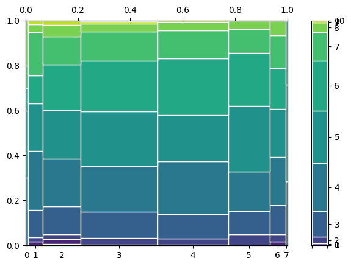

```python
xy = RV(Binomial(7, 0.5) * Binomial(10, 0.5)).sim(1000)
xy.plot(["mosaic"])
```

```python
xy = RV(Normal(0, 1) * Binomial(100, 0.5)).sim(1000)
xy.plot(["mosaic"])
```

```
---------------------------------------------------------------------------
Exception                                 Traceback (most recent call last)
Cell In[6], line 2
      1 xy = RV(Normal(0, 1) * Binomial(100, 0.5)).sim(1000)
----> 2 xy.plot(["mosaic"])

File ~\calpoly\ross\symbulate\symbulate\results.py:613, in RVResults.plot(self, type, alpha, normalize, jitter, bins, **kwargs)
    610             make_mosaic_marginal(self.array, ax_marg)
    612         elif not discrete_x or not discrete_y:
--> 613             raise Exception("Mosaic plots can only be made "
    614                             "for 2 discrete random variables.")
    615 else:
    616     if alpha is None:

Exception: Mosaic plots can only be made for 2 discrete random variables.
```

Improvements to make: all simulated values have a tick mark on their respective axis, which results in overcrowding

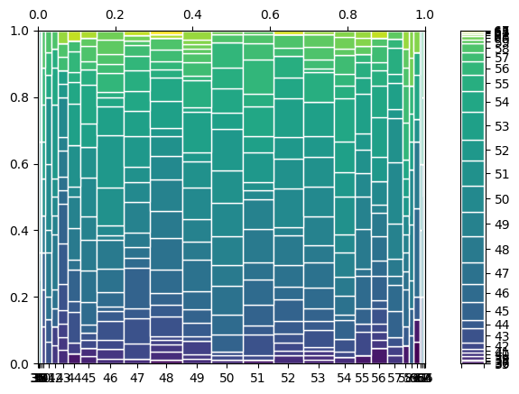

```python
xy = RV(Binomial(100, 0.5) * Binomial(100, 0.5)).sim(1000)
xy.plot(["mosaic"])
```

# Tile Plot

Improved by fixing overcrowded axes for discrete variables

Changed color map to viridis

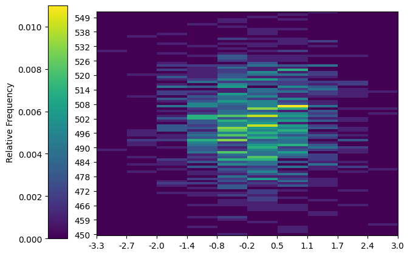

```python
xy = RV(Normal(0,1) * Binomial(1000, 0.5)).sim(1000)
xy.plot(["tile"])
```

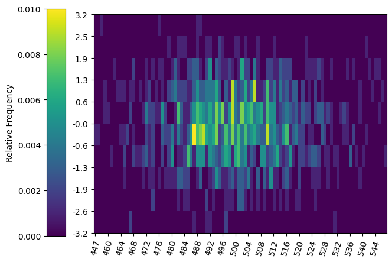

```python
xy = RV(Binomial(1000, 0.5) * Normal(0,1)).sim(1000)
xy.plot(["tile"])
```

# 2D Histogram

Improved by reducing to appropriate amount of bins for discrete variables with small support

Changed color map to viridis

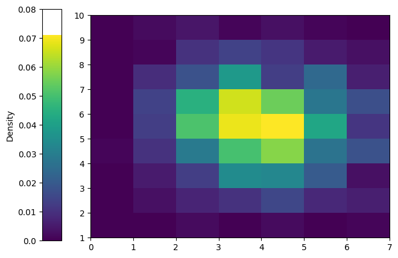

```python
xy = RV(Binomial(7, 0.5) * Binomial(10, 0.5)).sim(1000)
xy.plot(["hist"])
```

# Density Plot

Changed color map to viridis

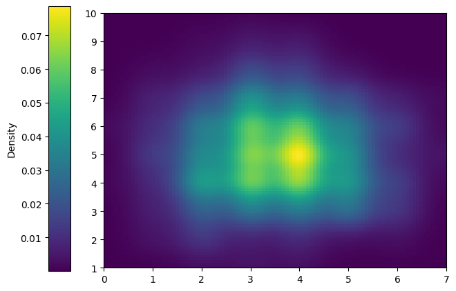

```python
xy = RV(Binomial(7, 0.5) * Binomial(10, 0.5)).sim(1000)
xy.plot(["density"])
```

# Distribution PDF Plot Shading

- Changed .plot() to a chainable method for distributions
- Added .shade() chainable method that shades areas under curve based on parameters (lt, gt, le, ge)
- Shades area under curve if continuous distribution
- Adds impulse lines under curve if discrete distribution
- Adds impulse line at le/ge if specified and distribution is continuous
- Returns error if lt/le value is less than gt/ge value
- Returns error if both lt and le specified
- Returns error if both gt and ge specified

Continuous Example:

```
<symbulate.distributions.Normal at 0x19b075dde50>
```

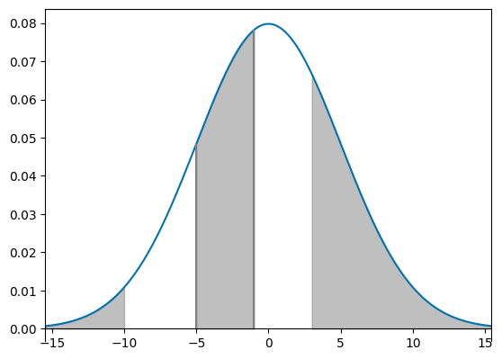

```python
Normal(0,5).plot().shade(lt=-10).shade(le=-1,ge=-5).shade(gt=3)
```

Discrete Example:

```
<symbulate.distributions.Poisson at 0x19b06ed4940>
```

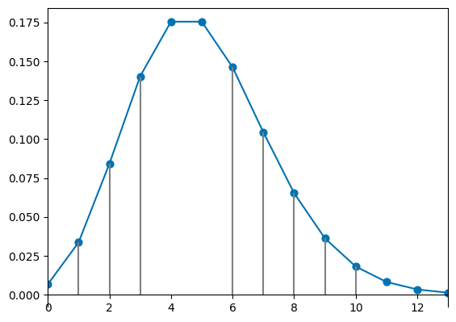

```python
Poisson(5).shade(lt=3.3).shade(le=10,ge=6)
```

# Distribution CDF Plot Option

- Added cdf option to .plot() method for distributions
- Displays CDF plot as continuous function for continuous variables
- Displays CDF plot as stepwise function for discrete variables

```
<symbulate.distributions.Normal at 0x19b071e62e0>
```

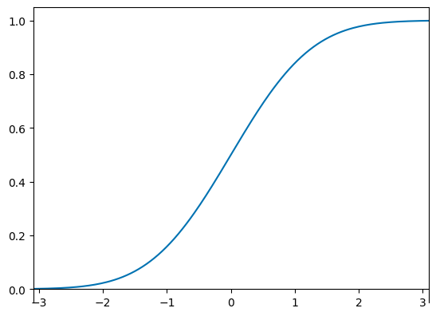

```python
Normal().plot(cdf=True)
```

```
<symbulate.distributions.Poisson at 0x19b08c704c0>
```

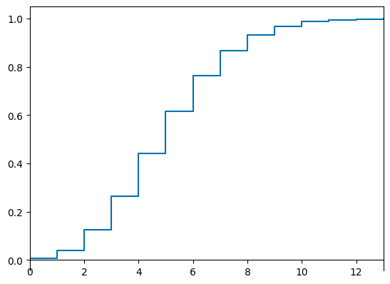

```python
Poisson(5).plot(cdf=True)
```

# ECDF Plot

- Created ECDF plot type for single RVs

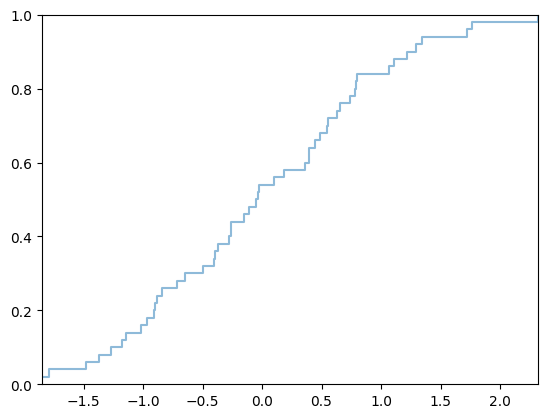

```python
X = RV(Normal()).sim(50)
X.plot(["ecdf"])
```

With theoretical CDF plot overlay:

```
<symbulate.distributions.Normal at 0x19b09656760>
```

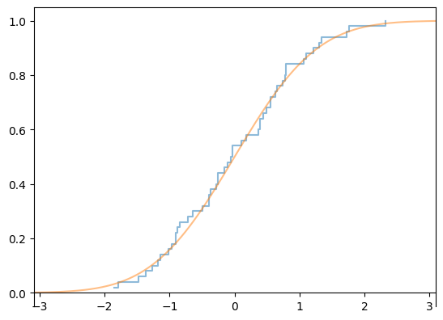

```python
X.plot(["ecdf"])
Normal().plot(cdf=True, alpha=0.5)
```